# EDA Assignment 5

Motoki Sugino

10/16/2016

### 1. Find some (x, y) data where you think x and y are strongly related. Make a scatterplot and find the least-squares and resistant fits. Plot the two sets of residuals. Interpret the fit and the residuals. Contrast the two methods of fitting – is it better to fit a resistant line?

scatter plot

```r
library(LearnEDA)
library(datasets)
library(car)
head(women)
```

```
##   height weight
## 1     58    115
## 2     59    117
## 3     60    120
## 4     61    123
## 5     62    126
## 6     63    129
```

[figure not shown]

```r
plot(women$height, women$weight,main="Scatter plot")
curve(-84.7+3.4*x,add=TRUE, col="red")
abline(lm(weight ~ height, data = women))
legend("topleft",legend=c("LeastSquare","Resistant"),col=c("blue","red"),lty=1,lwd=2,cex=.8)
```

We can see that there is a positive trend which makes sense and weight and height are strongly related since the x and y are failling in straight lines.

find the least squares

```r
#find the least squares
coef(lm(weight ~ height, data = women))
```

```
## (Intercept)      height
##   -87.51667     3.45000
```

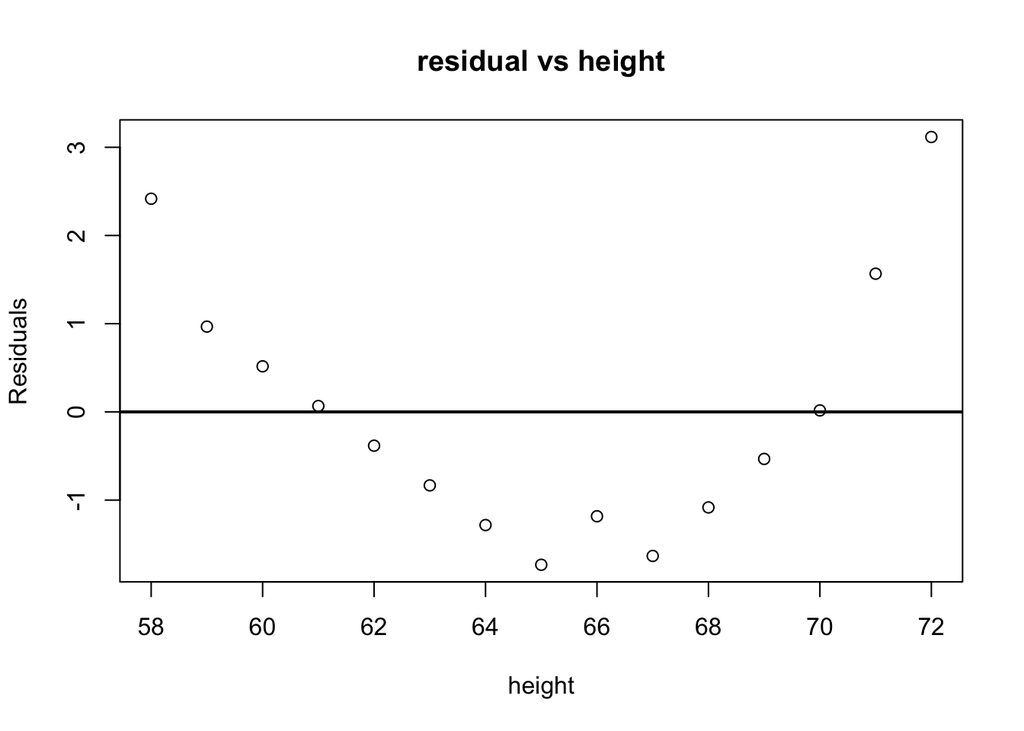

```r
# Calculate slope and intercept of line of best fit
myfit <- with(women,lm(weight ~ height))
RESIDUAL <- resid(myfit)
plot(women$height, RESIDUAL,ylab="Residuals",xlab="height",main="residual vs height")
abline(h = 0, lwd=2)
```

We can see that there is an obvious pattern in the residual ve height plot. The height between 62 and 69 have negative residuals.

Resistant fits

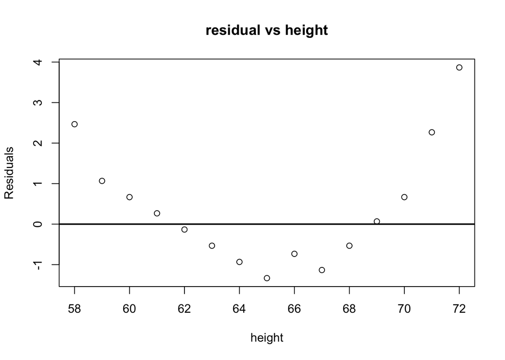

```r
#resistant fits
myfit <- with(women,rline(height, weight))
FIT <- with(myfit, a + b * (women$height - xC))
RESIDUAL <- myfit$residual
#options(digits=4)
#data.frame(women$height,women$weight,FIT, RESIDUAL)
plot(women$height, RESIDUAL,ylab="Residuals",xlab="height",main="residual vs height")
abline(h=0, lwd=2)
```

| Fitting Method | Fits |
| --- | --- |
| least-squares fit | $y=3.45000x-87.51667$ |
| resistant fit | $y=136.3+3.4(x-65)$ |

The slope is **m = 3.45**, so this means that the weight in women has generally been increasing,on average,by **3.45** when the height increases by one.

Contrast the two methods of fitting, we could see that there is no big difference in both a least square fit and a resistant fit in this data.

### 2. Fit a resistant line to the following data (population of England and Wales in millions for different years). Data is stored in the file pop.england in the LearnEDA package. Plot the residuals and summarize the results.

```r
data(pop.england)
head(pop.england)
```

```
##   YEAR POPULATION
## 1 1801       8.89
## 2 1811      10.16
## 3 1821      12.00
## 4 1831      13.90
## 5 1841      15.91
## 6 1851      17.93
```

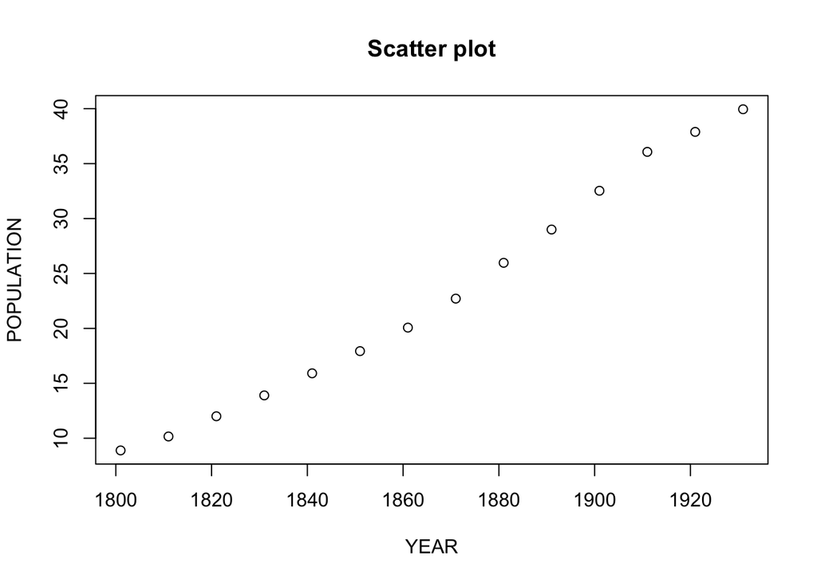

```r
with(pop.england,plot(YEAR,POPULATION,xlab="YEAR",ylab="POPULATION", main="Scatter plot"))
```

We can see that there is a positive trend which makes sense and YEAR and POPULATION are strongly related since the x and y are failling in straight lines.

Resistant fits

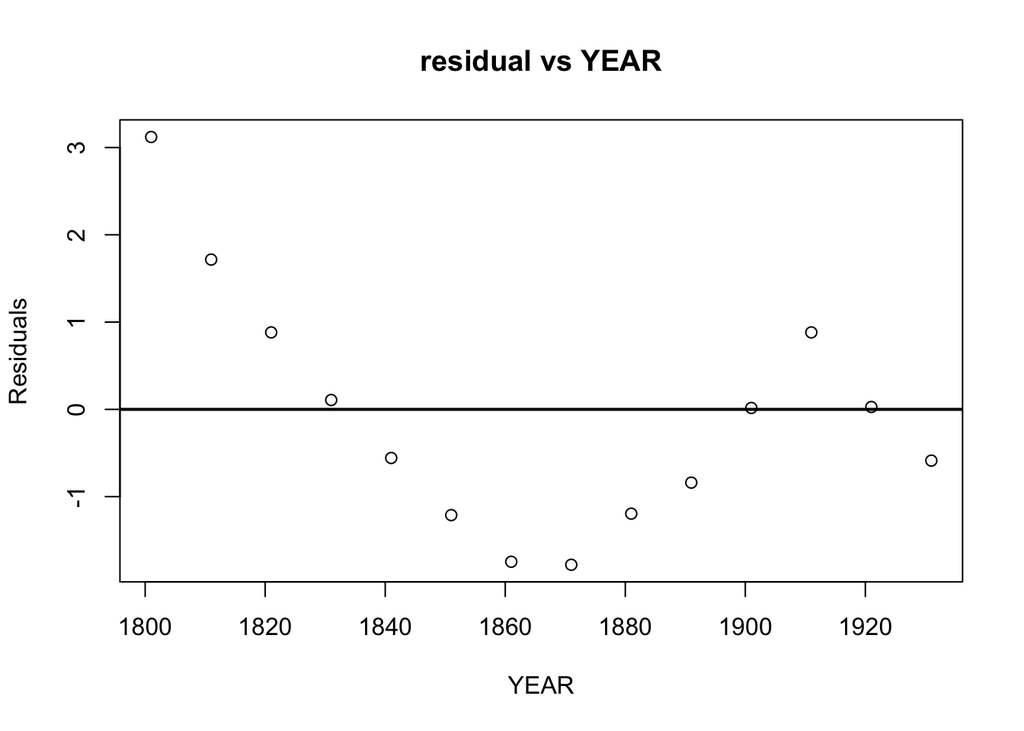

```r
#resistant fits
myfit <- with(pop.england,rline(YEAR, POPULATION))
FIT <- with(myfit, a + b * (pop.england$YEAR - xC))
RESIDUAL <- myfit$residual
#options(digits=4)
#data.frame(women$height,women$weight,FIT, RESIDUAL)
plot(pop.england$YEAR, RESIDUAL,ylab="Residuals",xlab="YEAR",main="residual vs YEAR")
abline(h=0, lwd=2)
```

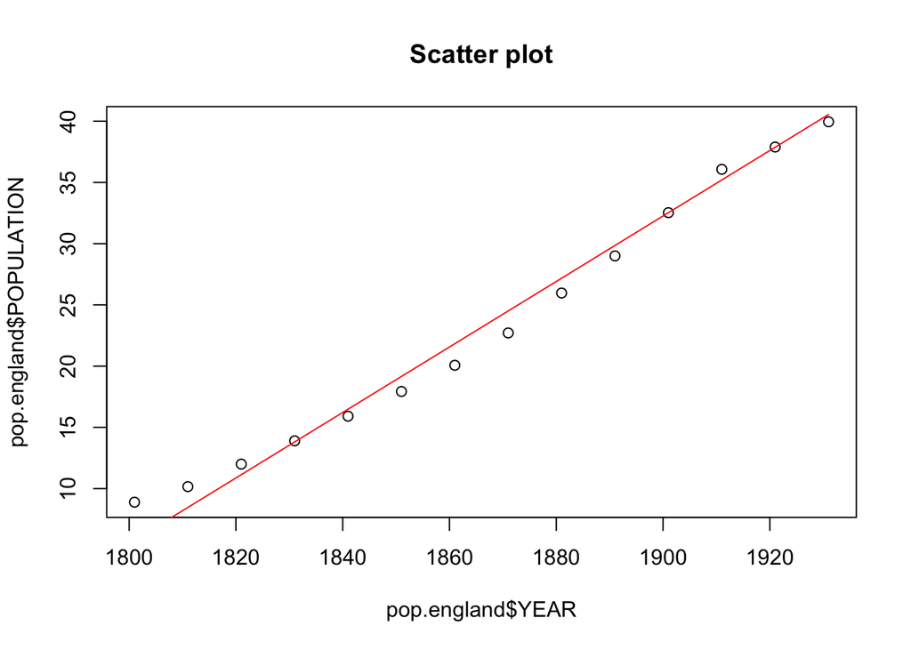

```r
plot(pop.england$YEAR, pop.england$POPULATION,main="Scatter plot")
curve(-475.8+0.2674*x,add=TRUE, col="red")
```

From the residual vs year plot, we can see that there is an obvious pattern therefore, the residuals are not constant. while there is the highest residual in 1800, there are extreamly lower residulas in year between 1860 and 1880. We can guess that something natural disaster or war might be happened at that time in England. We may need to transform the data to go further analysis.

### 3. For the following problems (from Tukey, EDA),

1. straighten plot using transformations applied on summary points
2. fit a line to the transformed plots and plot the residuals
3. summarize all results

```r
head(tukey.26a)
```

```
##   temp rate
## 1   21  248
## 2   22  308
## 3   23  388
## 4   24  465
## 5   25  569
## 6   26  678
```

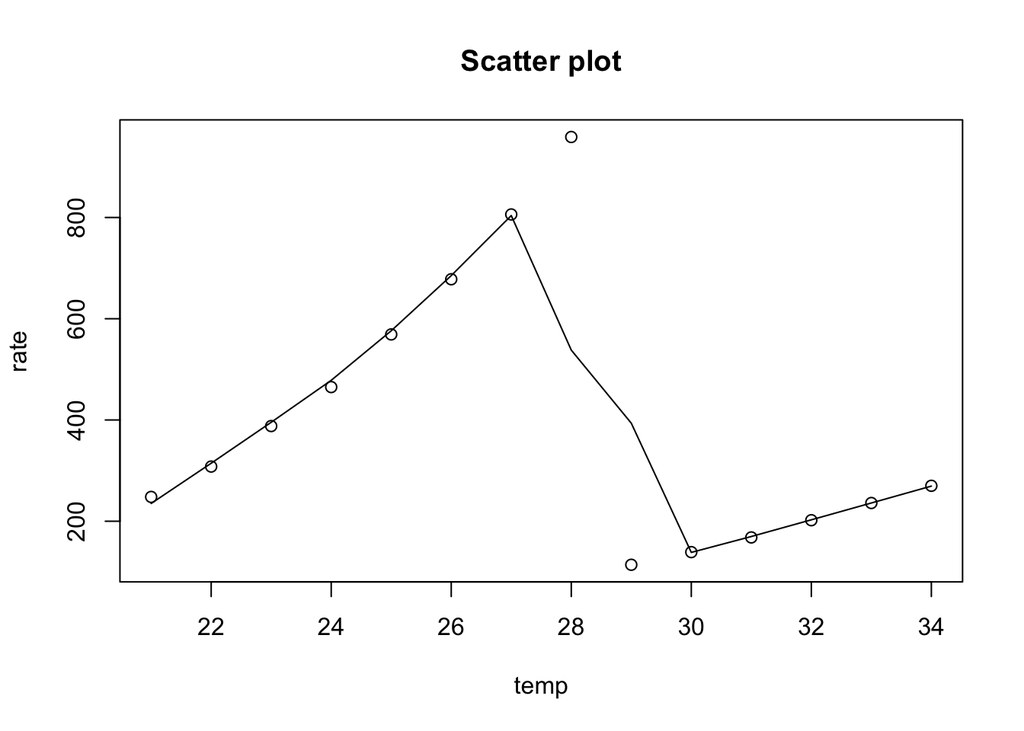

```r
with(tukey.26a,plot(temp,rate,xlab="temp",ylab="rate", main="Scatter plot"))
with(tukey.26a,lines(lowess(temp, rate, f=0.5)))
```

we can see that data is jumping after temparature 28. Therefore, we need to split the data into two parts.

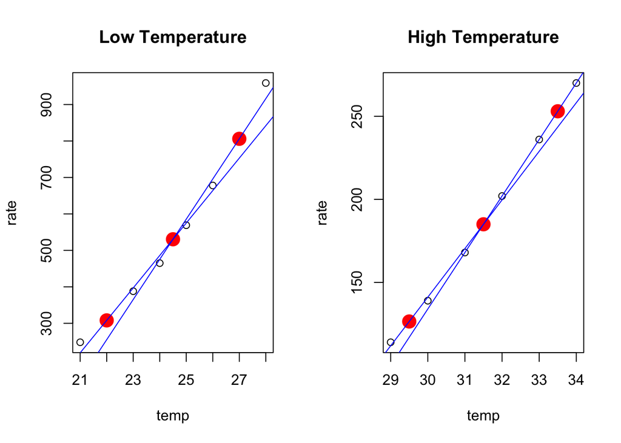

```r
low=tukey.26a[1:8,]
high=tukey.26a[9:14,]
par(mfrow=c(1,2))
# For low, we have 8 points so a symmetric way to go assigns 3,2,3 to the groups.#
with(low,plot(temp,rate,main = "Low Temperature"))
summary.pointsLow <- data.frame(x = c(22,24.5,27),
                                y = c(308,530.5,806))
points(summary.pointsLow, cex=2, pch=19, col="red")
abline(lm(y ~ x, data=summary.pointsLow[1:2, ]), col="blue")
abline(lm(y ~ x, data=summary.pointsLow[2:3, ]), col="blue")

# For low, we have 6 points so a symmetric way to go assigns 2,2,2 to the groups.#
with(high,plot(temp,rate,main="High Temperature"))
summary.pointsHigh <- data.frame(x = c(29.5,31.5,33.5),
                                 y = c(126.5,185,253))
points(summary.pointsHigh,cex=2, pch=19, col="red")
abline(lm(y ~ x, data=summary.pointsHigh[1:2, ]), col="blue")
abline(lm(y ~ x, data=summary.pointsHigh[2:3, ]), col="blue")
```

```r
par(mfrow=c(1,1))
```

$(x, y)=(temp,rate)$

[output not shown]

Straightening

```r
straightening.work <- function(sp, px, py){
sp$tx <- with(sp, (x ^ px - 1) / px)
sp$ty <- with(sp, (y ^ py - 1) / py)
sp$slope[1] <- with(sp, diff(ty[1:2]) / diff(tx[1:2]))
sp$slope[2] <- with(sp, diff(ty[2:3]) / diff(tx[2:3]))
sp$half.slope.ratio <- with(sp, slope[2] / slope[1])
sp$slope[3] <- NA
sp$half.slope.ratio[2:3] <- NA
row.names(sp) <- c("Left", "Center", "Right")
sp}
```

The bulge in both curvatures are towards large x and small y. We would like to make half slope ratio close to the goal value of 1.

Straightening for low temperature

```r
straightening.work(summary.pointsLow, 1, 1)
```

```
##           x     y   tx    ty slope half.slope.ratio
## Left   22.0 308.0 21.0 307.0  89.0         1.238202
## Center 24.5 530.5 23.5 529.5 110.2               NA
## Right  27.0 806.0 26.0 805.0    NA               NA
```

```r
straightening.work(summary.pointsLow, 0.5, 1)#Taking a square root of x#
```

```
##           x     y       tx    ty    slope half.slope.ratio
## Left   22.0 308.0 7.380832 307.0 428.9873          1.30316
## Center 24.5 530.5 7.899495 529.5 559.0391               NA
## Right  27.0 806.0 8.392305 805.0       NA               NA
```

```r
straightening.work(summary.pointsLow, 0.5, 0.5)#Taking a square root of x and a square root of y#
```

```
##           x     y       tx       ty    slope half.slope.ratio
## Left   22.0 308.0 7.380832 33.09986 21.14148         1.028446
## Center 24.5 530.5 7.899495 44.06517 21.74288               NA
## Right  27.0 806.0 8.392305 54.78028       NA               NA
```

The half-slope ratio is bHS = 1.028, so it appears that we’ve straightened the plot by transforming x to take a quare root of x and a quare root of y.

Straightening for high temperature

```r
straightening.work(summary.pointsHigh, 1, 1)
```

```
##           x     y   tx    ty slope half.slope.ratio
## Left   29.5 126.5 28.5 125.5 29.25         1.162393
## Center 31.5 185.0 30.5 184.0 34.00               NA
## Right  33.5 253.0 32.5 252.0    NA               NA
```

```r
straightening.work(summary.pointsHigh, 0.5, 1)#Taking a square root of x#
```

```
##           x     y       tx    ty    slope half.slope.ratio
## Left   29.5 126.5 8.862780 125.5 161.5167         1.199919
## Center 31.5 185.0 9.224972 184.0 193.8069               NA
## Right  33.5 253.0 9.575837 252.0       NA               NA
```

```r
straightening.work(summary.pointsHigh, 0.5, 0.5)#Taking a square root of x and a square root of y#
```

```
##           x     y       tx       ty    slope half.slope.ratio
## Left   29.5 126.5 8.862780 20.49444 13.00002         1.010471
## Center 31.5 185.0 9.224972 25.20294 13.13613               NA
## Right  33.5 253.0 9.575837 29.81195       NA               NA
```

The half-slope ratio is bHS = 1.01, so it appears that we’ve straightened the plot by transforming x to take a quare root of x and a quare root of y.

Transforming both data.

```r
par(mfrow=c(1,2))
#for low#
new.x <- - low$temp ^ (0.5)
new.y <- - low$rate ^ (0.5)
plot(new.x, new.y)
fit <- rline(new.x, new.y, iter=5)
c(fit$a, fit$b, fit$xC)
```

```
## [1] -22.97163  21.43450  -4.94949
```

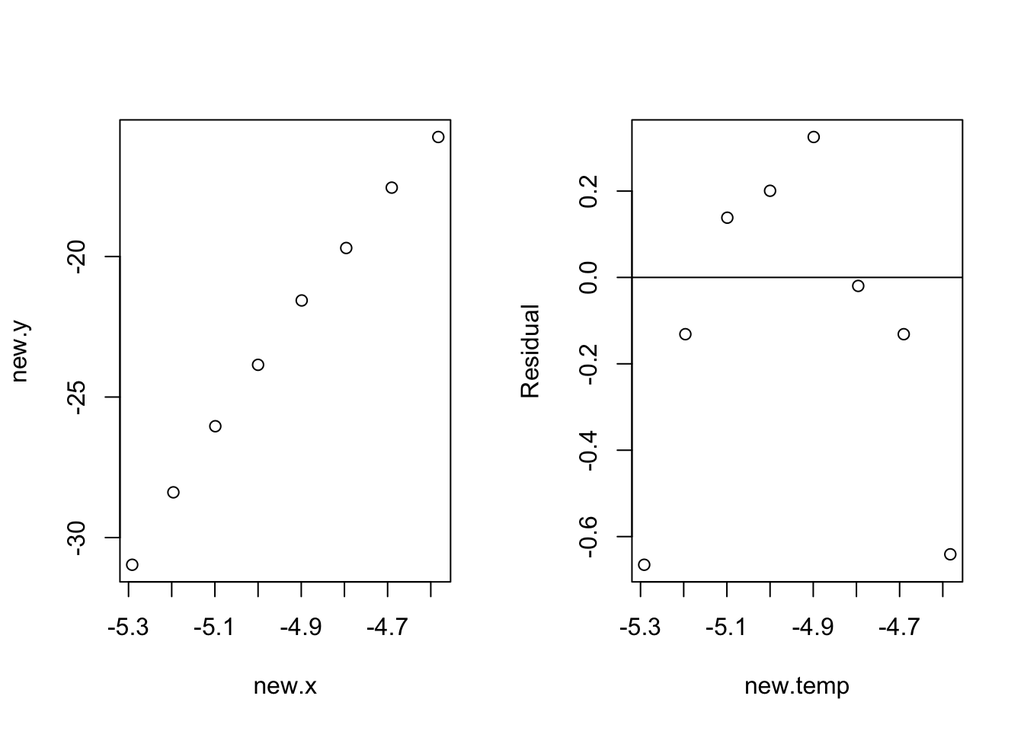

```r
#The residuals from this line fit are shown below.#
plot(new.x, fit$residual, ylab="Residual",xlab="new.temp")
abline(h=0)
```

summarize for low temperature.

We fit a line shown below – it has intercept −22.972, slope 21.434, and xC = −4.949. Our line fit is : $sqrt(y)=-22.972+21.434*(sqrt(x)-4.949)$

In the scatterplot, we are successful to see the liner relationship. I might see any obvious curvature in the residual plot. This means that we might not be successful in straightening the association pattern in the graph.

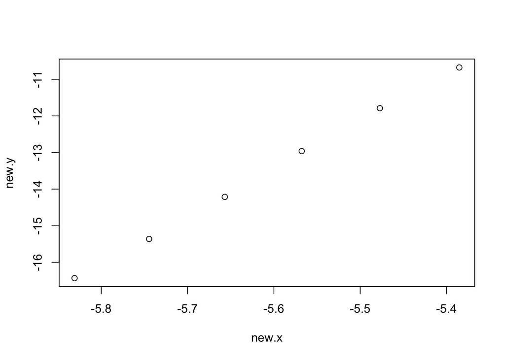

```r
#for high#
new.x <- - high$temp ^ (0.5)
new.y <- - high$rate ^ (0.5)
plot(new.x, new.y)
```

```r
fit <- rline(new.x, new.y, iter=5)
c(fit$a, fit$b, fit$xC)
```

```
## [1] -13.597207  13.079158  -5.612309
```

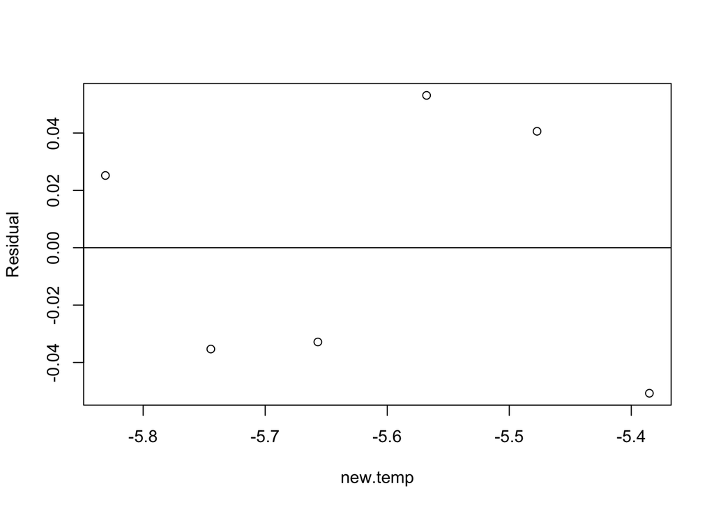

```r
#The residuals from this line fit are shown below.#
plot(new.x, fit$residual, ylab="Residual",xlab="new.temp")
abline(h=0)
```

```r
par(mfrow=c(1,1))
```

summarize for high temperature.

First, I don’t see any obvious curvature in the plot. This means that we were successful in straightening the association pattern in the graph. There might be one unusual observation in the right corner. We might need to check the temperature which is the higher than 29 (-5.385 in new temp data).

#### For tukey.26b

```r
head(tukey.26b)
```

```
##   year deposits
## 1   37      458
## 2   38      498
## 3   39      523
## 4   40      643
## 5   41      707
## 6   42      787
```

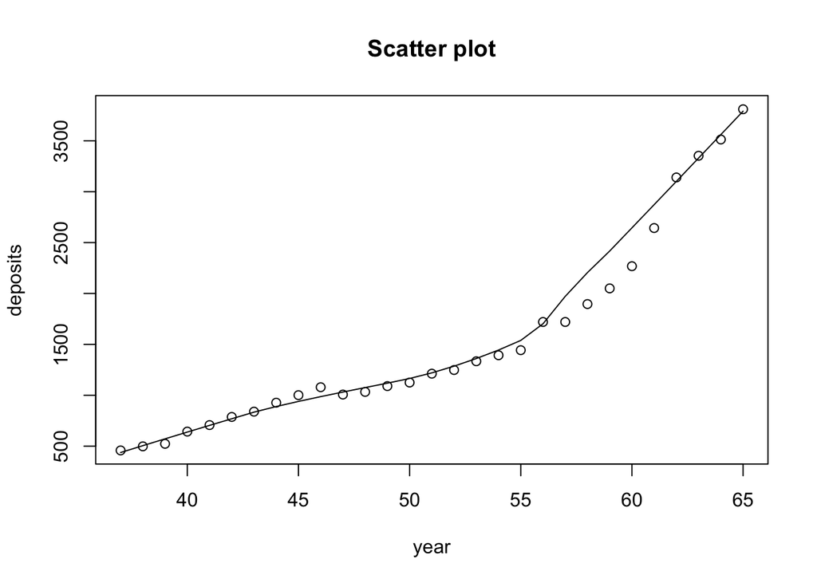

```r
with(tukey.26b,plot(year,deposits,xlab="year",ylab="deposits", main="Scatter plot"))
with(tukey.26b,lines(lowess(year, deposits, f=0.5)))
```

we can see that there is a slightly curved relationship between year and deposits so there is not a straight-line relationship

Three summary points we have **29** points so a symmetric way to go assigns **10,9,10** to the groups.

```r
data <- data.frame(tukey.26b$year, tukey.26b$deposits)
sorted.data <- data[order(tukey.26b$year), ]
round(sorted.data, 2)
```

```
##    tukey.26b.year tukey.26b.deposits
## 1              37                458
## 2              38                498
## 3              39                523
## 4              40                643
## 5              41                707
## 6              42                787
## 7              43                839
## 8              44                927
## 9              45               1001
## 10             46               1079
## 11             47               1007
## 12             48               1033
## 13             49               1090
## 14             50               1125
## 15             51               1212
## 16             52               1248
## 17             53               1334
## 18             54               1393
## 19             55               1443
## 20             56               1720
## 21             57               1720
## 22             58               1896
## 23             59               2050
## 24             60               2268
## 25             61               2643
## 26             62               3140
## 27             63               3353
## 28             64               3513
## 29             65               3810
```

$(x, y)=(year,deposits)$

| left summary point | center summary point | right summary point |
| --- | --- | --- |
| $(xL, yL)=(41.5,747)$ | $(xC, yC)=(51,1212)$ | $(xR, yR)=(60.5,2455.5)$ |

These points are plotted as red dots in the figure below.

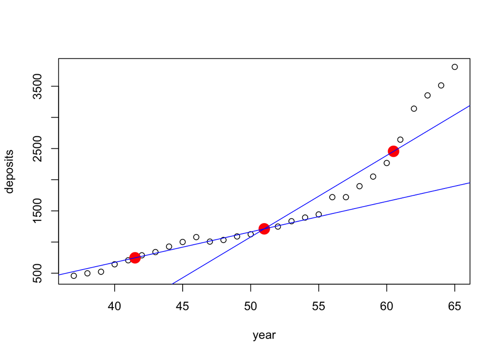

```r
with(tukey.26b,
plot(year, deposits))
summary.points <- data.frame(x = c(41.5, 51, 60.5),
y = c(747, 1212, 2455.5))
points(summary.points, cex=2, pch=19, col="red")
abline(lm(y ~ x, data=summary.points[1:2, ]), col="blue")
abline(lm(y ~ x, data=summary.points[2:3, ]), col="blue")
```

The bulge in both curvatures are towards large x and small y. We would like to make half slope ratio close to the goal value of 1.

Straightening

```r
straightening.work(summary.points, 1, 1)
```

```
##           x      y   tx     ty     slope half.slope.ratio
## Left   41.5  747.0 40.5  746.0  48.94737         2.674194
## Center 51.0 1212.0 50.0 1211.0 130.89474               NA
## Right  60.5 2455.5 59.5 2454.5        NA               NA
```

```r
straightening.work(summary.points, 0.5, 1)#Taking a square root of x#
```

```
##           x      y       tx     ty    slope half.slope.ratio
## Left   41.5  747.0 10.88410  746.0 332.4377         2.937238
## Center 51.0 1212.0 12.28286 1211.0 976.4488               NA
## Right  60.5 2455.5 13.55635 2454.5       NA               NA
```

```r
straightening.work(summary.points, 0.5, 0.5)#Taking a square root of x and a square root of y#
```

```
##           x      y       tx       ty    slope half.slope.ratio
## Left   41.5  747.0 10.88410 52.66260 10.69876         2.163587
## Center 51.0 1212.0 12.28286 67.62758 23.14770               NA
## Right  60.5 2455.5 13.55635 97.10600       NA               NA
```

```r
straightening.work(summary.points, -0.5, -1)#by transforming x to the -0.5 power and y to the -1 power#
```

```
##           x      y       tx        ty      slope half.slope.ratio
## Left   41.5  747.0 1.689540 0.9986613 0.01689259         1.078881
## Center 51.0 1212.0 1.719944 0.9991749 0.01822509               NA
## Right  60.5 2455.5 1.742870 0.9995928         NA               NA
```

The half-slope ratio is bHS = 1.079, so it appears that we’ve straightened the plot by transforming x to the -0.5 power and y to the -1 power.

Transforming both data.

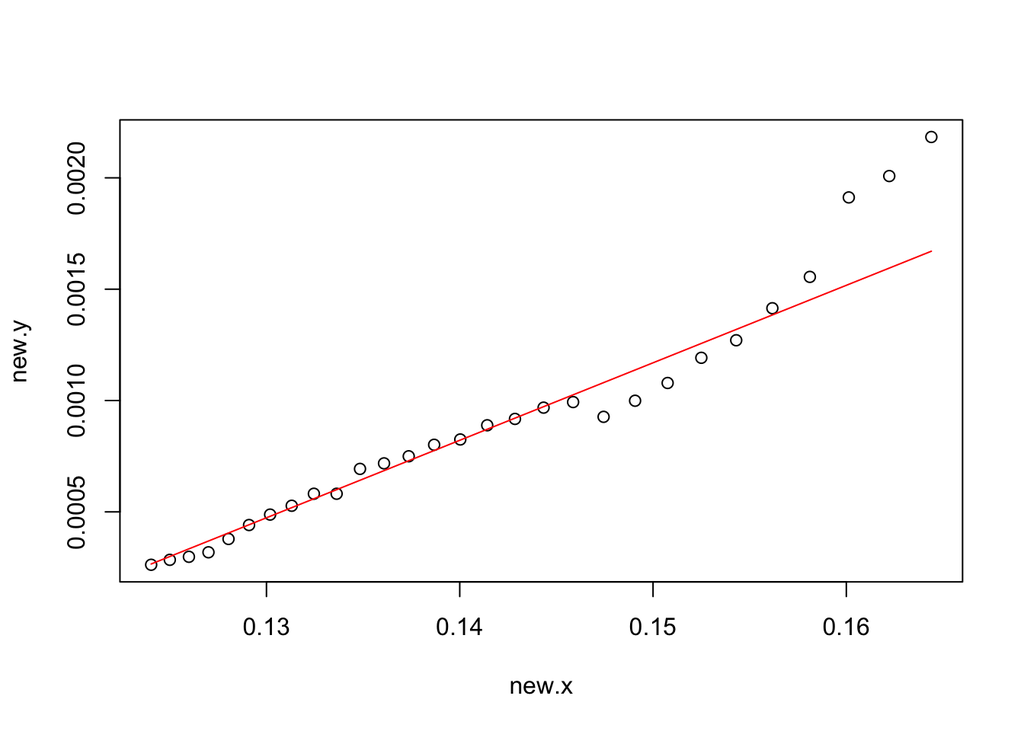

```r
new.x <-  tukey.26b$year ^ (-0.5)
new.y <-  tukey.26b$deposits ^ (-1)
plot(new.x, new.y)
curve(-0.00405+0.0347961*x,add=TRUE, col="red")
```

```r
fit <- rline(new.x, new.y, iter=5)
c(fit$a, fit$b, fit$xC) #FIT <- with(myfit, a + b * (tukey.26b$year - xC))
```

```
## [1] 0.0008223152 0.0347961306 0.1400280084
```

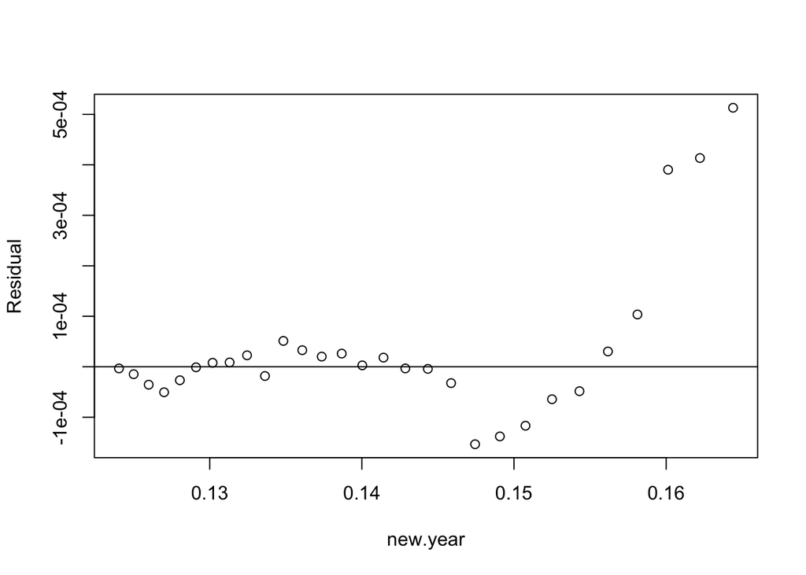

```r
plot(new.x, fit$residual, ylab="Residual",xlab="new.year")#The residuals from this line fit are shown below.#
abline(h=0)
```

summarize.

In the residual plot, I might see an obvious curvature in end after 0.15. However,the residual looks very constant in between 0.12 to 0.1474 (after year 1945). This means that we might not be successful in straightening the association pattern in the graph. However,we might be successful in straightening the association pattern in the graph for after 1945.

#### For tukey.26c

```r
head(tukey.26c)
```

```
##   year miles
## 1   37   412
## 2   38   480
## 3   39   683
## 4   40  1052
## 5   41  1385
## 6   42  1418
```

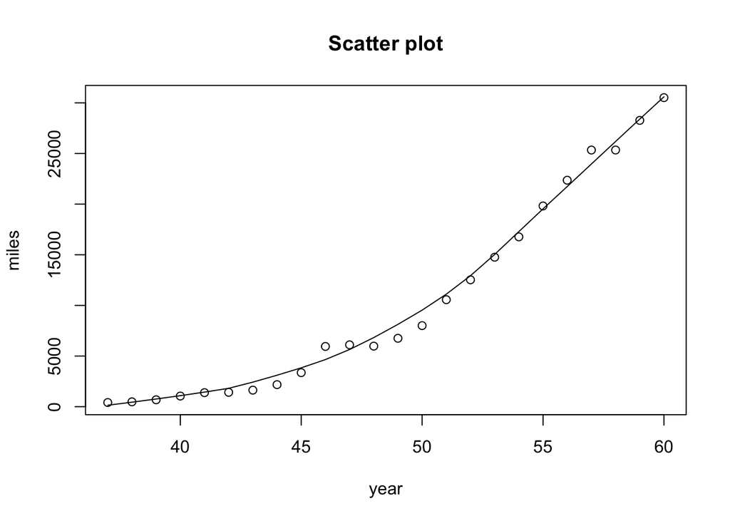

```r
with(tukey.26c,plot(year,miles,xlab="year",ylab="miles", main="Scatter plot"))
with(tukey.26c,lines(lowess(year, miles, f=0.5)))
```

we can see that there is a slightly curved relationship between year and miles so there is not a straight-line relationship

Three summary points we have **24** points so a symmetric way to go assigns **8,8,8** to the groups.

```r
data <- data.frame(tukey.26c$year, tukey.26c$miles)
sorted.data <- data[order(tukey.26c$year), ]
round(sorted.data, 2)
```

```
##    tukey.26c.year tukey.26c.miles
## 1              37             412
## 2              38             480
## 3              39             683
## 4              40            1052
## 5              41            1385
## 6              42            1418
## 7              43            1634
## 8              44            2178
## 9              45            3362
## 10             46            5948
## 11             47            6109
## 12             48            5981
## 13             49            6753
## 14             50            8003
## 15             51           10566
## 16             52           12528
## 17             53           14760
## 18             54           16769
## 19             55           19819
## 20             56           22362
## 21             57           25340
## 22             58           25343
## 23             59           28269
## 24             60           30514
```

$(x, y)=(year,miles)$

[output not shown]

These points are plotted as red dots in the figure below.

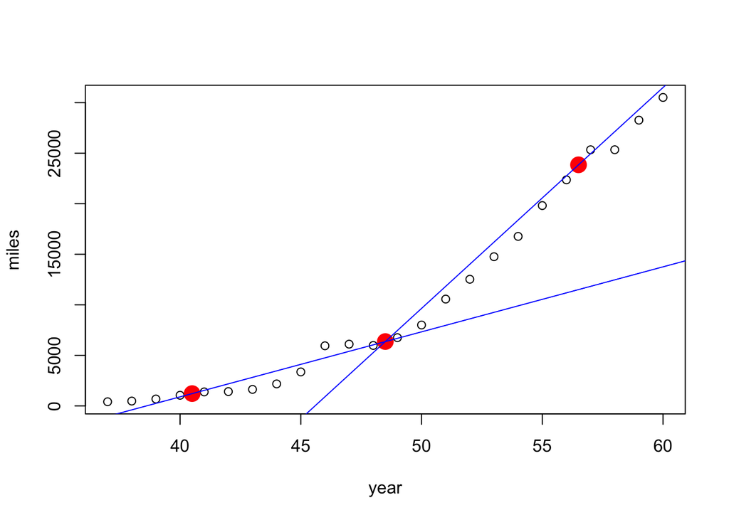

```r
with(tukey.26c,
plot(year, miles))
summary.points <- data.frame(x = c(40.5, 48.5, 56.5),
y = c(1218.5, 6367, 23851))
points(summary.points, cex=2, pch=19, col="red")
abline(lm(y ~ x, data=summary.points[1:2, ]), col="blue")
abline(lm(y ~ x, data=summary.points[2:3, ]), col="blue")
```

The bulge in both curvatures are towards large x and small y. We would like to make half slope ratio close to the goal value of 1.

Straightening

```r
straightening.work(summary.points, 1, 1)
```

```
##           x       y   tx      ty     slope half.slope.ratio
## Left   40.5  1218.5 39.5  1217.5  643.5625         3.395941
## Center 48.5  6367.0 47.5  6366.0 2185.5000               NA
## Right  56.5 23851.0 55.5 23850.0        NA               NA
```

```r
straightening.work(summary.points, 0.5, 1)#Taking a square root of x#
```

```
##           x       y       tx      ty    slope half.slope.ratio
## Left   40.5  1218.5 10.72792  1217.5  4288.75         3.689639
## Center 48.5  6367.0 11.92839  6366.0 15823.94               NA
## Right  56.5 23851.0 13.03330 23850.0       NA               NA
```

```r
straightening.work(summary.points, 0.5, 0.5)#Taking a square root of x and a square root of y#
```

```
##           x       y       tx        ty     slope half.slope.ratio
## Left   40.5  1218.5 10.72792  67.81404  74.78172         1.806777
## Center 48.5  6367.0 11.92839 157.58697 135.11387               NA
## Right  56.5 23851.0 13.03330 306.87538        NA               NA
```

```r
straightening.work(summary.points, 0.05, 0.05)#by transforming x to the 0.05 power and y to the 0.05 power#
```

```
##           x       y       tx        ty    slope half.slope.ratio
## Left   40.5  1218.5 4.065935  8.531281 11.28597         1.007304
## Center 48.5  6367.0 4.283824 10.990368 11.36840               NA
## Right  56.5 23851.0 4.469913 13.105894       NA               NA
```

The half-slope ratio is bHS = **1.007**, so it appears that we’ve straightened the plot by transforming x to the **0.05** power and y to the **0.05** power.

Transforming both data.

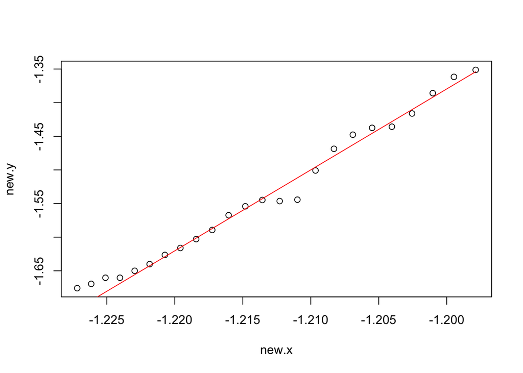

```r
new.x <- - tukey.26c$year ^ (0.05)
new.y <- - tukey.26c$miles ^ (0.05)
plot(new.x, new.y)
curve(13.06+12.033*x,add=TRUE, col="red")
```

```r
fit <- rline(new.x, new.y, iter=5)
c(fit$a, fit$b, fit$xC) #FIT <- with(myfit, a + b * (tukey.26c$year - xC))
```

```
## [1] -1.546227 12.033040 -1.214188
```

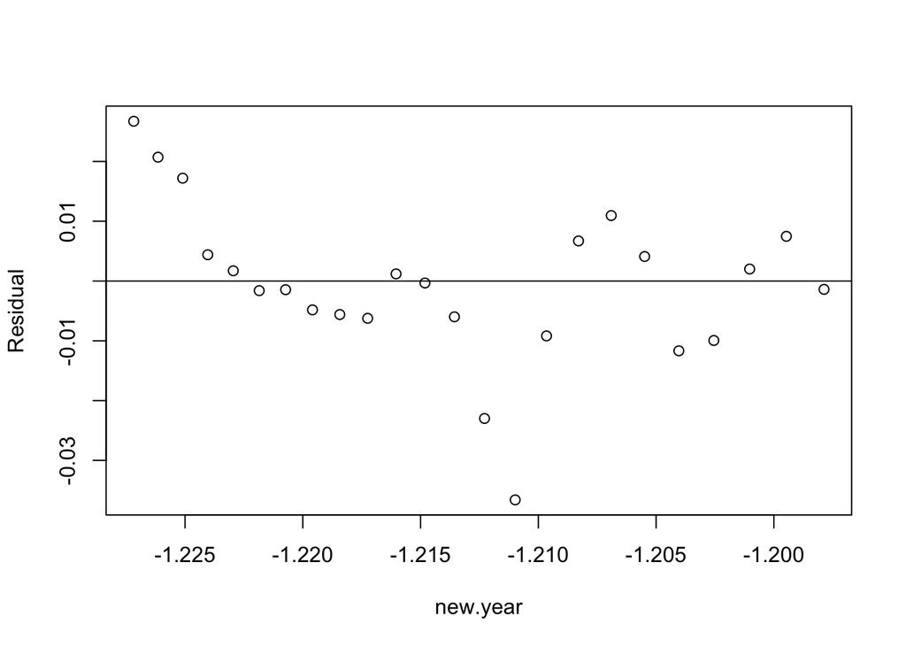

```r
plot(new.x, fit$residual, ylab="Residual",xlab="new.year")#The residuals from this line fit are shown below.#
abline(h=0)
```

summarize.

We fit a line shown below – it has intercept **-1.546**, slope **12.033**, and xC = **-1.214**. Our line fit is : $y ^{ (0.05)}=-1.546+12.033*(x^{ (0.05) }+ 1.214.)$

In the scatterplot, we are successful to see the liner relationship.

In the residual plot, there are unusual residuals which have higher residuals and a decreasing trend in the left side of the plot **(-1.225,-1.226,-1.227)**. This indicates that we might need to check year **1958**, **1959** and **1960**.

Furthermore, there is on obvious lower residual which is year **-1.211 (1946)**. This indicates that year **1946** has larger revenue passenger miles onU.S.domestic scheduled airlines.

However,other residuals might be successful in straightening the association pattern in the graph.